# project1

## Introduction

The objective of the dataset is to diagnostically predict whether or not a **patient has diabetes**, based on certain diagnostic measurements included in the dataset

## Objective:

To execute the following functions on the dataset

1. df.describe()
2. sns.pairplot
3. sns.pairplot - independent variables
4. box plot
5. scatter plot
6. outliers
7. missing values
8. strong correlation between variables
9. variables which are strong predictors

Addons:

1. To build a machine learning model to accurately predict whether or not the patients in the dataset have diabetes or not?

###### Load Libraries

```python
#import libraries
import pandas as pd
import numpy as np
import seaborn as sns
import matplotlib.pyplot as plt
%matplotlib inline

# Plots
import seaborn as sns
import matplotlib.pyplot as plt
%matplotlib inline
import plotly.offline as py
import plotly.graph_objs as go
from plotly.offline import download_plotlyjs, init_notebook_mode, plot, iplot
import plotly.tools as tls
import plotly.figure_factory as ff
py.init_notebook_mode(connected=True)
```

##### Load CSV file

```python
#Load CSV using Pandas
df=pd.read_csv('/Users/admin-mac/PycharmProjects/GL_all_tests/project1_pima_1/diabetes.csv')
```

##### Display 1st 10 rows

```python
df.head(10)
```

|  | Pregnancies | Glucose | BloodPressure | SkinThickness | Insulin | BMI | DiabetesPedigreeFunction | Age | Outcome |
| --- | --- | --- | --- | --- | --- | --- | --- | --- | --- |
| 0 | 6 | 148 | 72 | 35 | 0 | 33.6 | 0.627 | 50 | 1 |
| 1 | 1 | 85 | 66 | 29 | 0 | 26.6 | 0.351 | 31 | 0 |
| 2 | 8 | 183 | 64 | 0 | 0 | 23.3 | 0.672 | 32 | 1 |
| 3 | 1 | 89 | 66 | 23 | 94 | 28.1 | 0.167 | 21 | 0 |
| 4 | 0 | 137 | 40 | 35 | 168 | 43.1 | 2.288 | 33 | 1 |
| 5 | 5 | 116 | 74 | 0 | 0 | 25.6 | 0.201 | 30 | 0 |
| 6 | 3 | 78 | 50 | 32 | 88 | 31.0 | 0.248 | 26 | 1 |
| 7 | 10 | 115 | 0 | 0 | 0 | 35.3 | 0.134 | 29 | 0 |
| 8 | 2 | 197 | 70 | 45 | 543 | 30.5 | 0.158 | 53 | 1 |
| 9 | 8 | 125 | 96 | 0 | 0 | 0.0 | 0.232 | 54 | 1 |

##### Display last 10 rows

```python
df.tail(10)
```

|  | Pregnancies | Glucose | BloodPressure | SkinThickness | Insulin | BMI | DiabetesPedigreeFunction | Age | Outcome |
| --- | --- | --- | --- | --- | --- | --- | --- | --- | --- |
| 758 | 1 | 106 | 76 | 0 | 0 | 37.5 | 0.197 | 26 | 0 |
| 759 | 6 | 190 | 92 | 0 | 0 | 35.5 | 0.278 | 66 | 1 |
| 760 | 2 | 88 | 58 | 26 | 16 | 28.4 | 0.766 | 22 | 0 |
| 761 | 9 | 170 | 74 | 31 | 0 | 44.0 | 0.403 | 43 | 1 |
| 762 | 9 | 89 | 62 | 0 | 0 | 22.5 | 0.142 | 33 | 0 |
| 763 | 10 | 101 | 76 | 48 | 180 | 32.9 | 0.171 | 63 | 0 |
| 764 | 2 | 122 | 70 | 27 | 0 | 36.8 | 0.340 | 27 | 0 |
| 765 | 5 | 121 | 72 | 23 | 112 | 26.2 | 0.245 | 30 | 0 |
| 766 | 1 | 126 | 60 | 0 | 0 | 30.1 | 0.349 | 47 | 1 |
| 767 | 1 | 93 | 70 | 31 | 0 | 30.4 | 0.315 | 23 | 0 |

```python
df.shape
```

```
(768, 9)
```

```python
#Display column names
df.columns
```

```
Index(['Pregnancies', 'Glucose', 'BloodPressure', 'SkinThickness', 'Insulin',
       'BMI', 'DiabetesPedigreeFunction', 'Age', 'Outcome'],
      dtype='object')
```

```python
df.info()
# The following info suggests that:
# 1. There are no NULL values in this dataset
# 2. All fields are Numeric (INT and FLOAT)
```

```
<class 'pandas.core.frame.DataFrame'>
RangeIndex: 768 entries, 0 to 767
Data columns (total 9 columns):
Pregnancies                 768 non-null int64
Glucose                     768 non-null int64
BloodPressure               768 non-null int64
SkinThickness               768 non-null int64
Insulin                     768 non-null int64
BMI                         768 non-null float64
DiabetesPedigreeFunction    768 non-null float64
Age                         768 non-null int64
Outcome                     768 non-null int64
dtypes: float64(2), int64(7)
memory usage: 54.1 KB
```

All **fields** are **Numeric** (INT and FLOAT)

```python
# Generate descriptive statistics that summarize the central tendency, dispersion and shape of a dataset’s distribution, excluding NaN values.
# Analyzes both numeric and object series, as well as DataFrame column sets of mixed data types.
df.describe()
```

|  | Pregnancies | Glucose | BloodPressure | SkinThickness | Insulin | BMI | DiabetesPedigreeFunction | Age | Outcome |
| --- | --- | --- | --- | --- | --- | --- | --- | --- | --- |
| count | 768.000000 | 768.000000 | 768.000000 | 768.000000 | 768.000000 | 768.000000 | 768.000000 | 768.000000 | 768.000000 |
| mean | 3.845052 | 120.894531 | 69.105469 | 20.536458 | 79.799479 | 31.992578 | 0.471876 | 33.240885 | 0.348958 |
| std | 3.369578 | 31.972618 | 19.355807 | 15.952218 | 115.244002 | 7.884160 | 0.331329 | 11.760232 | 0.476951 |
| min | 0.000000 | 0.000000 | 0.000000 | 0.000000 | 0.000000 | 0.000000 | 0.078000 | 21.000000 | 0.000000 |
| 25% | 1.000000 | 99.000000 | 62.000000 | 0.000000 | 0.000000 | 27.300000 | 0.243750 | 24.000000 | 0.000000 |
| 50% | 3.000000 | 117.000000 | 72.000000 | 23.000000 | 30.500000 | 32.000000 | 0.372500 | 29.000000 | 0.000000 |
| 75% | 6.000000 | 140.250000 | 80.000000 | 32.000000 | 127.250000 | 36.600000 | 0.626250 | 41.000000 | 1.000000 |
| max | 17.000000 | 199.000000 | 122.000000 | 99.000000 | 846.000000 | 67.100000 | 2.420000 | 81.000000 | 1.000000 |

Check if there are **any null** values

```python
df.isnull().values.any()
```

```
False
```

```python
df.isnull().sum()
```

```
Pregnancies                 0
Glucose                     0
BloodPressure               0
SkinThickness               0
Insulin                     0
BMI                         0
DiabetesPedigreeFunction    0
Age                         0
Outcome                     0
dtype: int64
```

**No Null values** in the dataset

## Check sum of all cells which has **"0"** in each field

```python
df.isin([0]).sum()
```

```
Pregnancies                 111
Glucose                       5
BloodPressure                35
SkinThickness               227
Insulin                     374
BMI                          11
DiabetesPedigreeFunction      0
Age                           0
Outcome                     500
dtype: int64
```

### 2. MISSING VALUES

#### Observations:

1. **Bloodpressure** cannot be 0
2. **Skin thickness** cannot be 0
3. **Insulin** cannot be 0(Not sure)
4. **BMI** cannot be 0

##### Replace "0" with NAN to fill it with a meaningful value later

```python
df[['Glucose','BloodPressure','SkinThickness','Insulin','BMI']] = df[['Glucose','BloodPressure','SkinThickness','Insulin','BMI']].replace(0,np.NaN)
```

```python
# Define missing plot to detect all missing values in dataset
def missing_plot(dataset, key) :
    null_feat = pd.DataFrame(len(dataset[key]) - dataset.isnull().sum(), columns = ['Count'])
    percentage_null = pd.DataFrame((len(dataset[key]) - (len(dataset[key]) - dataset.isnull().sum()))/len(dataset[key])*100, columns = ['Count'])
    percentage_null = percentage_null.round(2)

    trace = go.Bar(x = null_feat.index, y = null_feat['Count'] ,opacity = 0.8, text = percentage_null['Count'],  textposition = 'auto',marker=dict(color = '#7EC0EE',
            line=dict(color='#000000',width=1.5)))

    layout = dict(title =  "Missing Values (count & %)")

    fig = dict(data = [trace], layout=layout)
    py.iplot(fig)

# Plotting
missing_plot(df, 'Outcome')
```

[interactive chart not shown]

#### Using plotly library

Missing values :

1. Insulin = 48.7% (768-394)= 374
2. SkinThickness = 29.56% = 227
3. BloodPressure = 4.56% = 35
4. BMI = 1.43% = 11
5. Glucose = 0.65% = 5

```python
df.groupby('Outcome').size()
```

```
Outcome
0    500
1    268
dtype: int64
```

```python
data=df
# 2 datasets
D = data[(data['Outcome'] != 0)]
H = data[(data['Outcome'] == 0)]

#------------COUNT-----------------------
trace = go.Bar( x = data['Outcome'].value_counts().values.tolist(),
                y = ['healthy','diabetic' ],
                orientation = 'h',
                text=data['Outcome'].value_counts().values.tolist(),
                textfont=dict(size=15),
                textposition = 'auto',
                opacity = 0.8,marker=dict(
                color=['green', 'red'],
                line=dict(color='#000000',width=1.5)))

layout = dict(title =  'Count of Outcome variable')

fig = dict(data = [trace], layout=layout)
py.iplot(fig)

#------------PERCENTAGE-------------------
trace = go.Pie(labels = ['healthy','diabetic'], values = data['Outcome'].value_counts(),
               textfont=dict(size=15), opacity = 0.8,
               marker=dict(colors=['green', 'red'],
                           line=dict(color='#000000', width=1.5)))


layout = dict(title =  'Distribution of Outcome variable')

fig = dict(data = [trace], layout=layout)
py.iplot(fig)
```

[interactive chart not shown]

###### About the Pima Indian Diabetes Dataset-

The Pima Indian Diabetes Dataset consists of information on **768** of women population: **268** tested positive and **500** tested negative instances. Tested positive and tested negative indicates whether the patient is diabetic or not, respectively. Each instance is comprised of **8 attributes**, which are **all numeric**.

```python
# convert nan to 0(to check distribution of data and then replace with approapriate mean,median,mode wherever necesssary)
df=df.fillna(0)
```

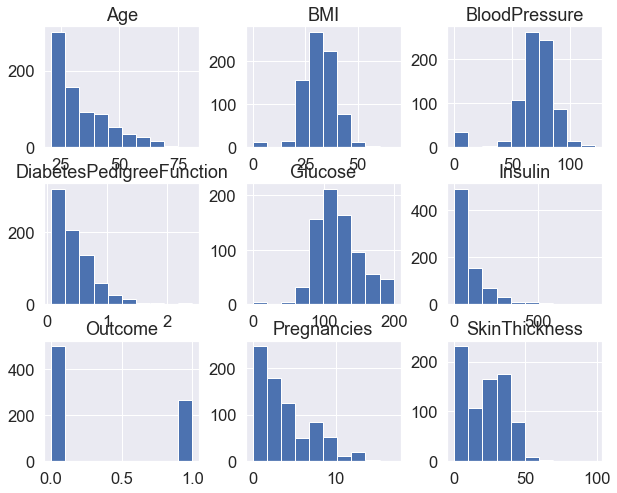

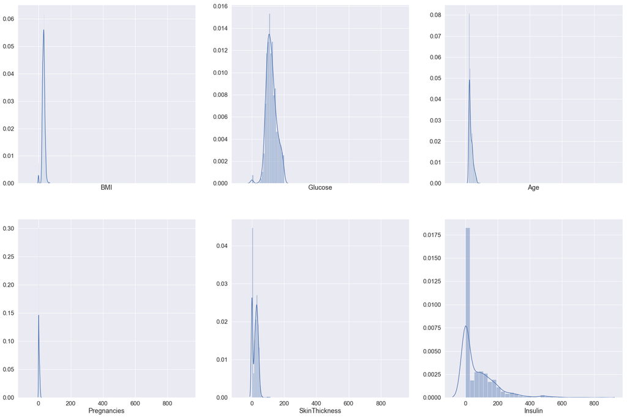

```python
df.hist(figsize=(10,8))
# df=df.fillna(0)
f, axes = plt.subplots(2, 3, figsize=(30, 20), sharex=True)
sns.distplot(df['BMI'],kde=True, ax=axes[0, 0])
sns.distplot(df['Glucose'],kde=True, ax=axes[0, 1])
sns.distplot(df['Age'],kde=True, ax=axes[0,2 ])
sns.distplot(df['Pregnancies'],kde=True, ax=axes[1, 0])
sns.distplot(df['SkinThickness'],kde=True, ax=axes[1, 1])
sns.distplot(df['Insulin'],kde=True, ax=axes[1, 2])
```

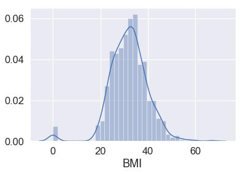

```python
sns.distplot(df['BMI'],kde=True)
```

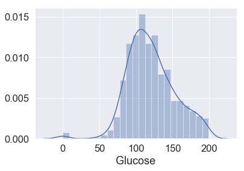

```python
sns.distplot(df['Glucose'],kde=True)
```

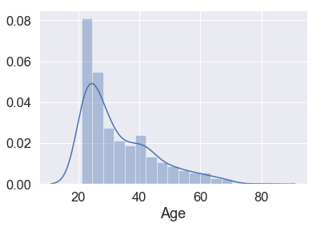

```python
sns.distplot(df['Age'],kde=True)
```

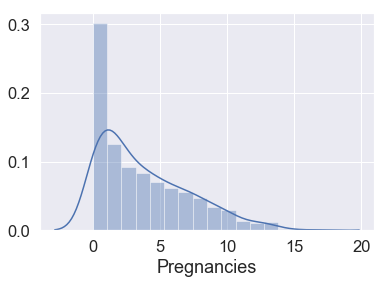

```python
sns.distplot(df['Pregnancies'],kde=True)
```

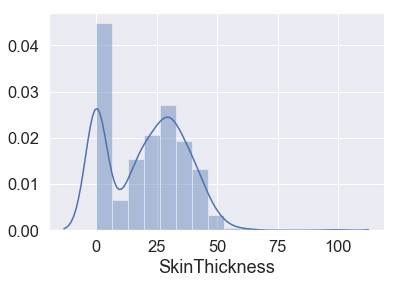

```python
sns.distplot(df['SkinThickness'],kde=True)
```

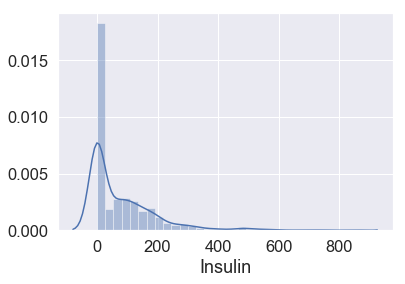

```python
sns.distplot(df['Insulin'],kde=True)
```

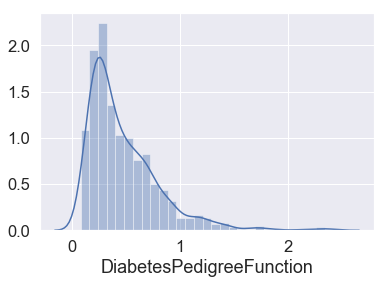

```python
sns.distplot(df['DiabetesPedigreeFunction'],kde=True)
```

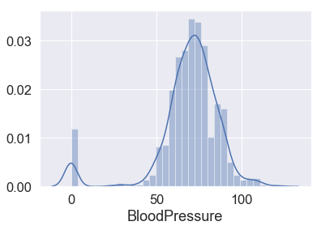

```python
sns.distplot(df['BloodPressure'],kde=True)
```

**Replace 0** with **mean** for the following columns:

1. BMI
2. GLUCOSE
3. BLOOD PRESSURE

As, they have almost perfect bell curve which indicates that the data is distributed equally on either sides

```python
df['Glucose'] = df['Glucose'].replace(0,df["Glucose"].mean())
df['BMI'] = df['BMI'].replace(0,df["BMI"].mean())
df['BloodPressure'] = df['BloodPressure'].replace(0,df["BloodPressure"].mean())
```

##### Implement pairplot:

To find correlation between **each variable** and the **"Outcome"**(Target) Variable

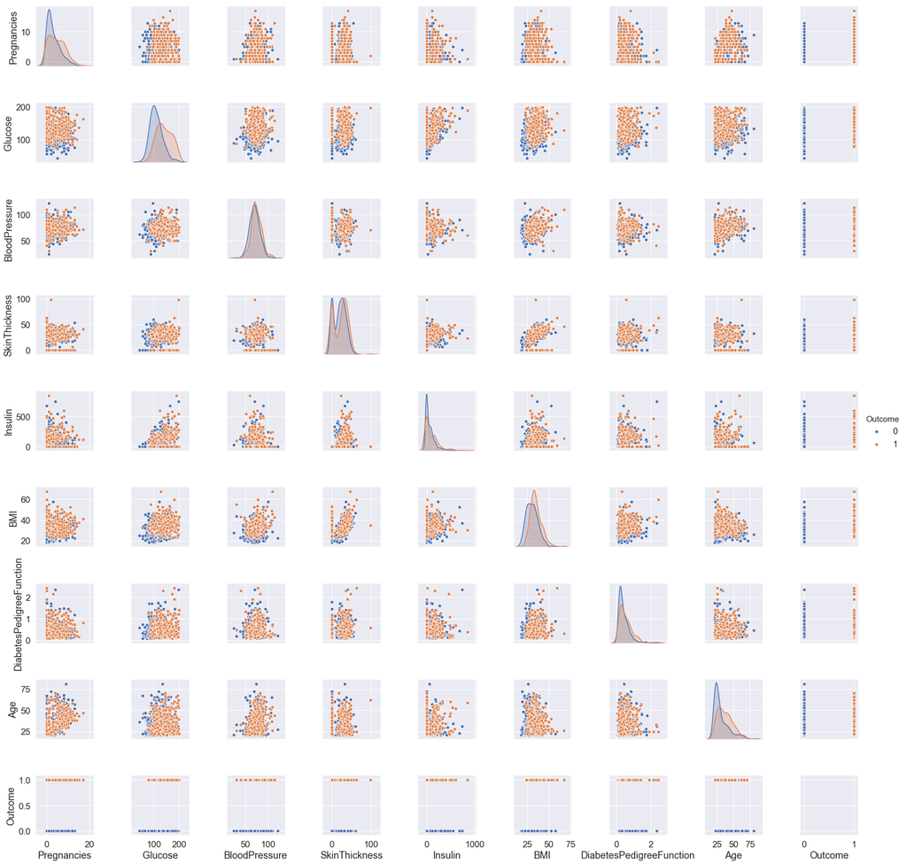

```python
sns.pairplot(data=df, hue='Outcome')
```

##### Pairplot Inference:

1. Pairplot with **Outcome** variables as **HUE**
2. There is a **correlation** between **Age** and **Pregnancies**
3. Digging in deeper to find which features effect the **Outcome**

```python
df.describe()
```

|  | Pregnancies | Glucose | BloodPressure | SkinThickness | Insulin | BMI | DiabetesPedigreeFunction | Age | Outcome |
| --- | --- | --- | --- | --- | --- | --- | --- | --- | --- |
| count | 768.000000 | 768.000000 | 768.000000 | 768.000000 | 768.000000 | 768.000000 | 768.000000 | 768.000000 | 768.000000 |
| mean | 3.845052 | 121.681605 | 72.254807 | 20.536458 | 79.799479 | 32.450805 | 0.471876 | 33.240885 | 0.348958 |
| std | 3.369578 | 30.436016 | 12.115932 | 15.952218 | 115.244002 | 6.875374 | 0.331329 | 11.760232 | 0.476951 |
| min | 0.000000 | 44.000000 | 24.000000 | 0.000000 | 0.000000 | 18.200000 | 0.078000 | 21.000000 | 0.000000 |
| 25% | 1.000000 | 99.750000 | 64.000000 | 0.000000 | 0.000000 | 27.500000 | 0.243750 | 24.000000 | 0.000000 |
| 50% | 3.000000 | 117.000000 | 72.000000 | 23.000000 | 30.500000 | 32.000000 | 0.372500 | 29.000000 | 0.000000 |
| 75% | 6.000000 | 140.250000 | 80.000000 | 32.000000 | 127.250000 | 36.600000 | 0.626250 | 41.000000 | 1.000000 |
| max | 17.000000 | 199.000000 | 122.000000 | 99.000000 | 846.000000 | 67.100000 | 2.420000 | 81.000000 | 1.000000 |

We can see that the differnece between **75% to max** for skin thickness, age, DiabetesPedigreeFunction and insulin is a lot! Few max values might be outliers. We can check it using BoxPlot.

##### Correlation Matrix

A matrix of correlations provides useful insight into relationships between pairs of variables.

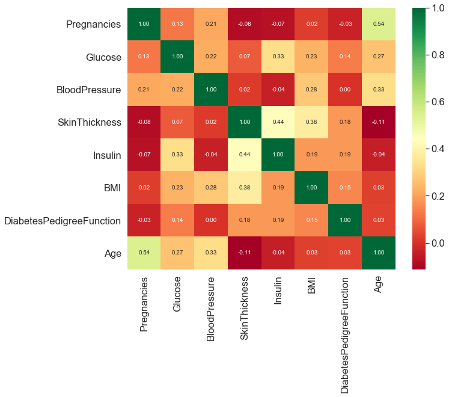

```python
X = df.loc[:,df.columns != 'Outcome']
sns.heatmap(
    data=X.corr(),
    annot=True,
    fmt='.2f',
    cmap='RdYlGn'
)

fig = plt.gcf()
fig.set_size_inches(10, 8)

plt.show()
```

##### Correlation Inference

1. Correlation exists between **Age** and **Pregnancies**
2. Correlation exists between **Insulin** and **Skin Thickness**

### Correlation value and Strength of Correlation:

[figure not shown]

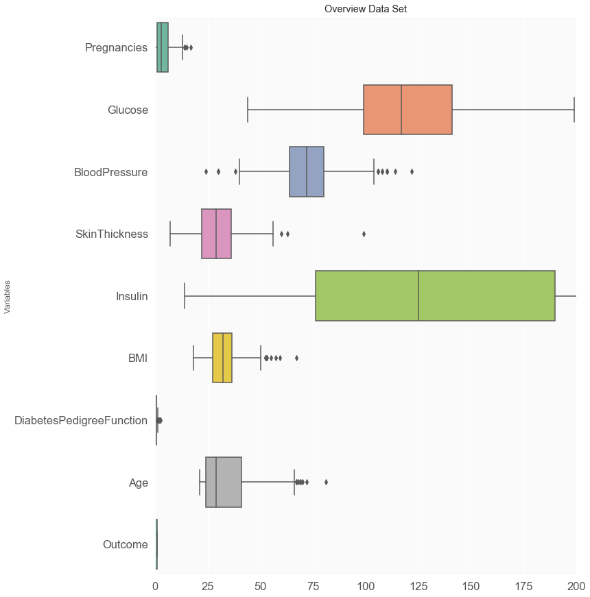

```python
plt.style.use('ggplot') # Using ggplot2 style visuals

f, ax = plt.subplots(figsize=(11, 15))

ax.set_facecolor('#fafafa')
ax.set(xlim=(-.05, 200))
plt.ylabel('Variables')
plt.title("Overview Data Set")
ax = sns.boxplot(data = data,
  orient = 'h',
  palette = 'Set2')
```

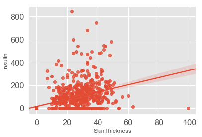

```python
sns.regplot(x='SkinThickness', y= 'Insulin', data=df)
```

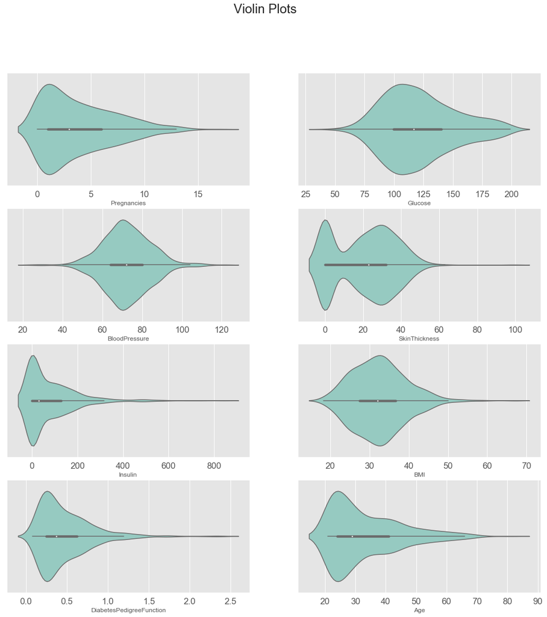

```python
fig,ax = plt.subplots(nrows=4, ncols=2, figsize=(18,18))
plt.suptitle('Violin Plots',fontsize=24)
sns.violinplot(x="Pregnancies", data=df,ax=ax[0,0],palette='Set3')
sns.violinplot(x="Glucose", data=df,ax=ax[0,1],palette='Set3')
sns.violinplot (x ='BloodPressure', data=df, ax=ax[1,0], palette='Set3')
sns.violinplot(x='SkinThickness', data=df, ax=ax[1,1],palette='Set3')
sns.violinplot(x='Insulin', data=df, ax=ax[2,0], palette='Set3')
sns.violinplot(x='BMI', data=df, ax=ax[2,1],palette='Set3')
sns.violinplot(x='DiabetesPedigreeFunction', data=df, ax=ax[3,0],palette='Set3')
sns.violinplot(x='Age', data=df, ax=ax[3,1],palette='Set3')
plt.show()
```

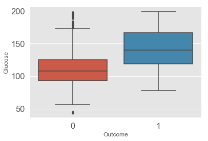

```python
sns.boxplot( data=df, x="Outcome", y="Glucose")
```

**Glucose** level above **140** is more likely to have **"Outcome"** category **1**

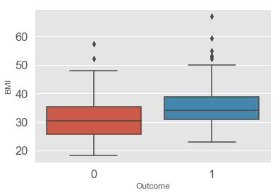

```python
sns.boxplot( data=df, x="Outcome", y="BMI")
```

**BMI** level above **35** is more likely to have **"Outcome"** category **1**

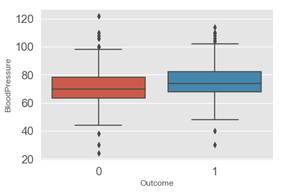

```python
sns.boxplot( data=df, x="Outcome", y="BloodPressure")
```

**No Significance** between **Blood Pressure** and **Outcome**

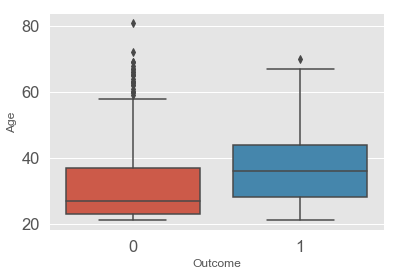

```python
sns.boxplot( data=df, x="Outcome", y="Age")
```

Age level above **35** is more likely to have **"Outcome" category 1**

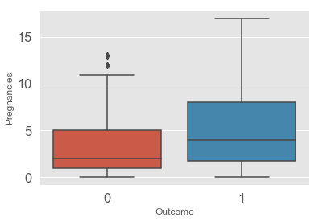

```python
sns.boxplot( data=df, x="Outcome", y="Pregnancies")
```

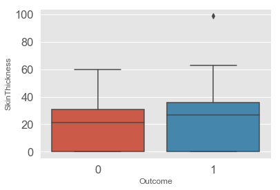

```python
sns.boxplot( data=df, x="Outcome", y="SkinThickness")
```

**No Significance** between **SkinThickness** and Outcome

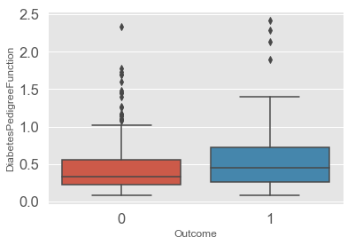

```python
sns.boxplot( data=df, x="Outcome", y="DiabetesPedigreeFunction")
```

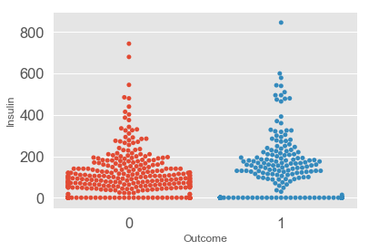

```python
sns.swarmplot(x='Outcome',y='Insulin',data=df)
```

The distribution is very similar. Not a big defference.

### Quadrant Analysis : Age and Glucose w.r.t Outcome

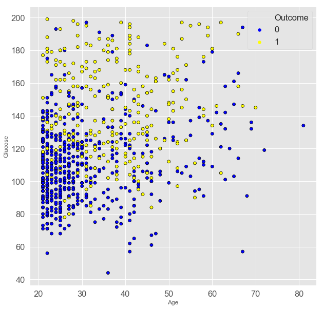

```python
fig = plt.figure(figsize=(10,10))
sns.scatterplot(x=df['Age'],y=df['Glucose'],hue=df['Outcome'],palette ={0:'Blue',1:'yellow'},edgecolor='black')
```

### Quadrant Analysis : DiabetesPedigreeFunction and Glucose w.r.t Outcome

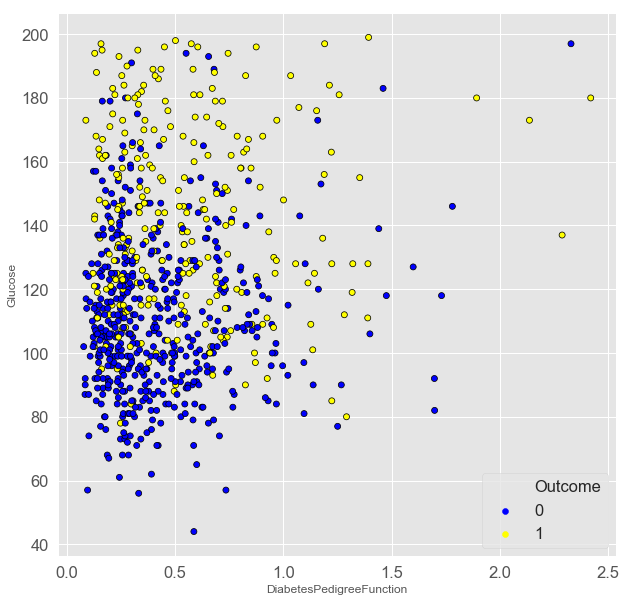

```python
fig = plt.figure(figsize=(10,10))
sns.scatterplot(x=df['DiabetesPedigreeFunction'],y=df['Glucose'],hue=df['Outcome'],palette ={0:'Blue',1:'yellow'},edgecolor='black')
```

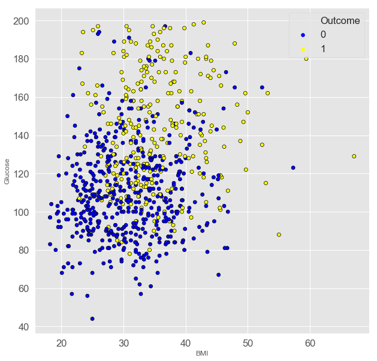

```python
fig = plt.figure(figsize=(10,10))
sns.scatterplot(x=df['BMI'],y=df['Glucose'],hue=df['Outcome'],palette ={0:'Blue',1:'yellow'},edgecolor='black')
```

**BMI** less than **30** and **Glucose** less than **100** has less chance to have **Outcome 1**

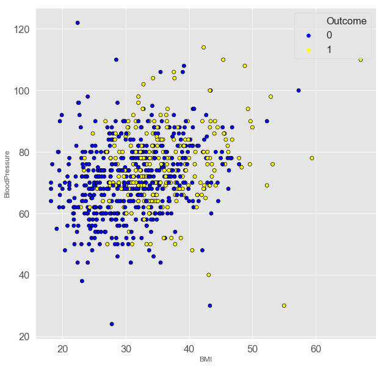

```python
fig = plt.figure(figsize=(10,10))
sns.scatterplot(x=df['BMI'],y=df['BloodPressure'],hue=df['Outcome'],palette ={0:'Blue',1:'yellow'},edgecolor='black')
```

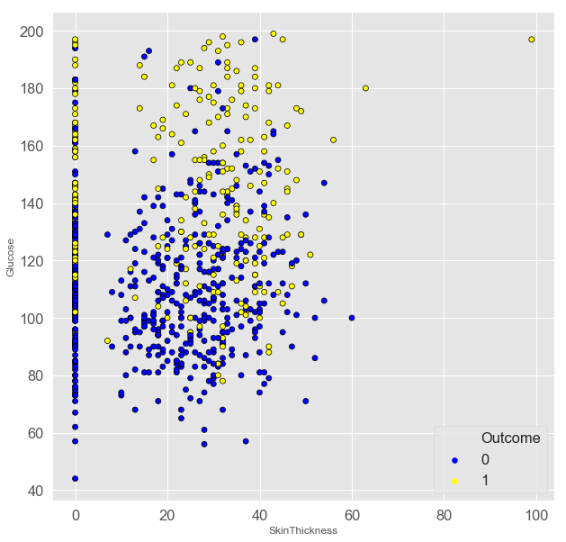

```python
fig = plt.figure(figsize=(10,10))
sns.scatterplot(x=df['SkinThickness'],y=df['Glucose'],hue=df['Outcome'],palette ={0:'Blue',1:'yellow'},edgecolor='black')
```

Glucose less than **90** and Skinthickness less than **25** has less chance to have **Outcome 1**

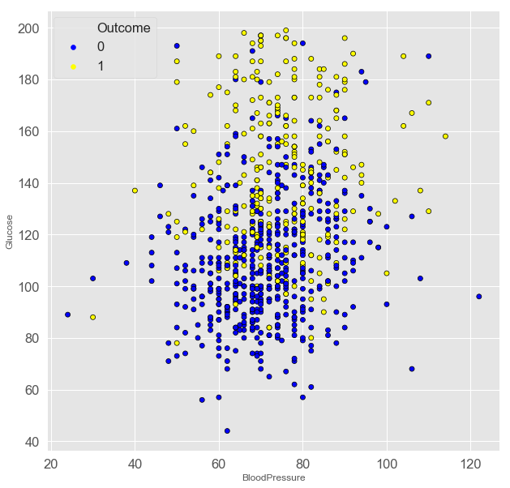

```python
fig = plt.figure(figsize=(10,10))
sns.scatterplot(x=df['BloodPressure'],y=df['Glucose'],hue=df['Outcome'],palette ={0:'Blue',1:'yellow'},edgecolor='black')
```

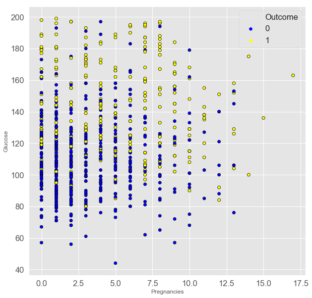

```python
fig = plt.figure(figsize=(10,10))
sns.scatterplot(x=df['Pregnancies'],y=df['Glucose'],hue=df['Outcome'],palette ={0:'Blue',1:'yellow'},edgecolor='black')
```

Pregnancies less than **6** and Glucose less than **120** has less chance to have **Outcome 1**

```python
age_buckets=[0,15,30,45,60,75,90,115]
df['buckets_age']= pd.cut(df['Age'],bins=age_buckets)

pregnancies_buckets=[0,2,4,6,8,10,12,14]
df['buckets_pregnancies']= pd.cut(df['Pregnancies'],bins=pregnancies_buckets)

df.head()
```

|  | Pregnancies | Glucose | BloodPressure | SkinThickness | Insulin | BMI | DiabetesPedigreeFunction | Age | Outcome | buckets_age | buckets_pregnancies |
| --- | --- | --- | --- | --- | --- | --- | --- | --- | --- | --- | --- |
| 0 | 6 | 148.0 | 72.0 | 35.0 | 0.0 | 33.6 | 0.627 | 50 | 1 | (45, 60] | (4.0, 6.0] |
| 1 | 1 | 85.0 | 66.0 | 29.0 | 0.0 | 26.6 | 0.351 | 31 | 0 | (30, 45] | (0.0, 2.0] |
| 2 | 8 | 183.0 | 64.0 | 0.0 | 0.0 | 23.3 | 0.672 | 32 | 1 | (30, 45] | (6.0, 8.0] |
| 3 | 1 | 89.0 | 66.0 | 23.0 | 94.0 | 28.1 | 0.167 | 21 | 0 | (15, 30] | (0.0, 2.0] |
| 4 | 0 | 137.0 | 40.0 | 35.0 | 168.0 | 43.1 | 2.288 | 33 | 1 | (30, 45] | NaN |

```python
data_df = pd.pivot_table(df,
              index=['buckets_age','buckets_pregnancies'],
                   columns = ['Outcome'],
               aggfunc=len)
data_df
```

| buckets_age | Outcome buckets_pregnancies | Age 0 | Age 1 | BMI 0 | BMI 1 | BloodPressure 0 | BloodPressure 1 | DiabetesPedigreeFunction 0 | DiabetesPedigreeFunction 1 | Glucose 0 | Glucose 1 | Insulin 0 | Insulin 1 | Pregnancies 0 | Pregnancies 1 | SkinThickness 0 | SkinThickness 1 |
| --- | --- | --- | --- | --- | --- | --- | --- | --- | --- | --- | --- | --- | --- | --- | --- | --- | --- |
| (15, 30] | (0, 2] | 172.0 | 25.0 | 172.0 | 25.0 | 172.0 | 25.0 | 172.0 | 25.0 | 172.0 | 25.0 | 172.0 | 25.0 | 172.0 | 25.0 | 172.0 | 25.0 |
|  | (2, 4] | 65.0 | 26.0 | 65.0 | 26.0 | 65.0 | 26.0 | 65.0 | 26.0 | 65.0 | 26.0 | 65.0 | 26.0 | 65.0 | 26.0 | 65.0 | 26.0 |
|  | (4, 6] | 27.0 | 8.0 | 27.0 | 8.0 | 27.0 | 8.0 | 27.0 | 8.0 | 27.0 | 8.0 | 27.0 | 8.0 | 27.0 | 8.0 | 27.0 | 8.0 |
|  | (6, 8] | 1.0 | 2.0 | 1.0 | 2.0 | 1.0 | 2.0 | 1.0 | 2.0 | 1.0 | 2.0 | 1.0 | 2.0 | 1.0 | 2.0 | 1.0 | 2.0 |
|  | (8, 10] | 1.0 | 2.0 | 1.0 | 2.0 | 1.0 | 2.0 | 1.0 | 2.0 | 1.0 | 2.0 | 1.0 | 2.0 | 1.0 | 2.0 | 1.0 | 2.0 |
| (30, 45] | (0, 2] | 13.0 | 15.0 | 13.0 | 15.0 | 13.0 | 15.0 | 13.0 | 15.0 | 13.0 | 15.0 | 13.0 | 15.0 | 13.0 | 15.0 | 13.0 | 15.0 |
|  | (2, 4] | 24.0 | 17.0 | 24.0 | 17.0 | 24.0 | 17.0 | 24.0 | 17.0 | 24.0 | 17.0 | 24.0 | 17.0 | 24.0 | 17.0 | 24.0 | 17.0 |
|  | (4, 6] | 27.0 | 16.0 | 27.0 | 16.0 | 27.0 | 16.0 | 27.0 | 16.0 | 27.0 | 16.0 | 27.0 | 16.0 | 27.0 | 16.0 | 27.0 | 16.0 |
|  | (6, 8] | 20.0 | 35.0 | 20.0 | 35.0 | 20.0 | 35.0 | 20.0 | 35.0 | 20.0 | 35.0 | 20.0 | 35.0 | 20.0 | 35.0 | 20.0 | 35.0 |
|  | (8, 10] | 15.0 | 16.0 | 15.0 | 16.0 | 15.0 | 16.0 | 15.0 | 16.0 | 15.0 | 16.0 | 15.0 | 16.0 | 15.0 | 16.0 | 15.0 | 16.0 |
|  | (10, 12] | 5.0 | 5.0 | 5.0 | 5.0 | 5.0 | 5.0 | 5.0 | 5.0 | 5.0 | 5.0 | 5.0 | 5.0 | 5.0 | 5.0 | 5.0 | 5.0 |
|  | (12, 14] | 3.0 | 6.0 | 3.0 | 6.0 | 3.0 | 6.0 | 3.0 | 6.0 | 3.0 | 6.0 | 3.0 | 6.0 | 3.0 | 6.0 | 3.0 | 6.0 |
| (45, 60] | (0, 2] | 3.0 | 6.0 | 3.0 | 6.0 | 3.0 | 6.0 | 3.0 | 6.0 | 3.0 | 6.0 | 3.0 | 6.0 | 3.0 | 6.0 | 3.0 | 6.0 |
|  | (2, 4] | 2.0 | 4.0 | 2.0 | 4.0 | 2.0 | 4.0 | 2.0 | 4.0 | 2.0 | 4.0 | 2.0 | 4.0 | 2.0 | 4.0 | 2.0 | 4.0 |
|  | (4, 6] | 9.0 | 12.0 | 9.0 | 12.0 | 9.0 | 12.0 | 9.0 | 12.0 | 9.0 | 12.0 | 9.0 | 12.0 | 9.0 | 12.0 | 9.0 | 12.0 |
|  | (6, 8] | 11.0 | 10.0 | 11.0 | 10.0 | 11.0 | 10.0 | 11.0 | 10.0 | 11.0 | 10.0 | 11.0 | 10.0 | 11.0 | 10.0 | 11.0 | 10.0 |
|  | (8, 10] | 6.0 | 10.0 | 6.0 | 10.0 | 6.0 | 10.0 | 6.0 | 10.0 | 6.0 | 10.0 | 6.0 | 10.0 | 6.0 | 10.0 | 6.0 | 10.0 |
|  | (10, 12] | 3.0 | 6.0 | 3.0 | 6.0 | 3.0 | 6.0 | 3.0 | 6.0 | 3.0 | 6.0 | 3.0 | 6.0 | 3.0 | 6.0 | 3.0 | 6.0 |
|  | (12, 14] | 2.0 | 1.0 | 2.0 | 1.0 | 2.0 | 1.0 | 2.0 | 1.0 | 2.0 | 1.0 | 2.0 | 1.0 | 2.0 | 1.0 | 2.0 | 1.0 |
| (60, 75] | (0, 2] | 2.0 | 2.0 | 2.0 | 2.0 | 2.0 | 2.0 | 2.0 | 2.0 | 2.0 | 2.0 | 2.0 | 2.0 | 2.0 | 2.0 | 2.0 | 2.0 |
|  | (2, 4] | 2.0 | 3.0 | 2.0 | 3.0 | 2.0 | 3.0 | 2.0 | 3.0 | 2.0 | 3.0 | 2.0 | 3.0 | 2.0 | 3.0 | 2.0 | 3.0 |
|  | (4, 6] | 7.0 | 1.0 | 7.0 | 1.0 | 7.0 | 1.0 | 7.0 | 1.0 | 7.0 | 1.0 | 7.0 | 1.0 | 7.0 | 1.0 | 7.0 | 1.0 |
|  | (6, 8] | 4.0 | NaN | 4.0 | NaN | 4.0 | NaN | 4.0 | NaN | 4.0 | NaN | 4.0 | NaN | 4.0 | NaN | 4.0 | NaN |
|  | (8, 10] | 1.0 | NaN | 1.0 | NaN | 1.0 | NaN | 1.0 | NaN | 1.0 | NaN | 1.0 | NaN | 1.0 | NaN | 1.0 | NaN |
|  | (10, 12] | 1.0 | NaN | 1.0 | NaN | 1.0 | NaN | 1.0 | NaN | 1.0 | NaN | 1.0 | NaN | 1.0 | NaN | 1.0 | NaN |
| (75, 90] | (8, 10] | 1.0 | NaN | 1.0 | NaN | 1.0 | NaN | 1.0 | NaN | 1.0 | NaN | 1.0 | NaN | 1.0 | NaN | 1.0 | NaN |

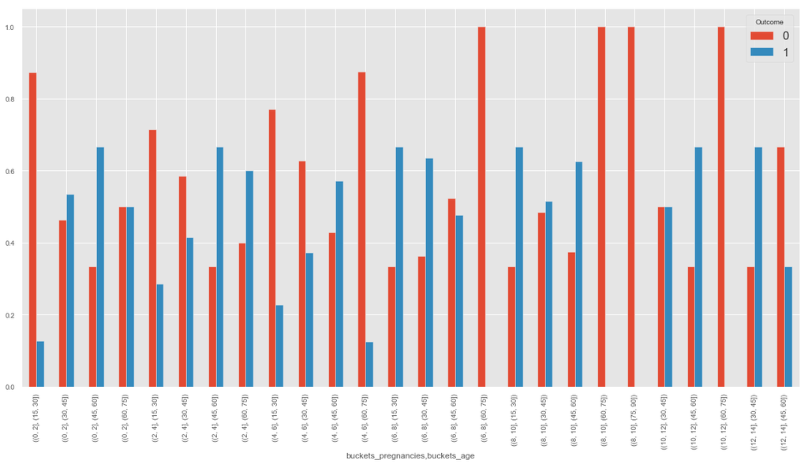

```python
data_crosstab = pd.crosstab([df['buckets_pregnancies'],df['buckets_age']],df['Outcome'], normalize='index')
data_crosstab.plot(kind="bar",figsize=(20,10),fontsize=10)
```

**OR**

# END OF PROJECT

## Trying few extra steps

### Using Feature selection

```python
from sklearn.ensemble import RandomForestClassifier
from sklearn.feature_selection import RFECV

X = df.drop(['Outcome','buckets_age','buckets_pregnancies'], axis=1)
y = df.Outcome

m = RFECV(RandomForestClassifier(), scoring='accuracy')
```

```python
X.dtypes
```

```
Pregnancies                   int64
Glucose                     float64
BloodPressure               float64
SkinThickness               float64
Insulin                     float64
BMI                         float64
DiabetesPedigreeFunction    float64
Age                           int64
dtype: object
```

```python
# df["Glucose"] = df["Glucose"].astype(float)
# df['Glucose'] =df['Glucose'].astype('float64')
# df['BloodPressure'] = pd.to_numeric(df['BloodPressure'], errors='coerce')
# df['BMI'] = pd.to_numeric(df['BMI'], errors='coerce')
```

```python
m.fit(X, y)
```

[output not shown]

[output cut: 64 more lines]

[output not shown]

```
RFECV(cv='warn',
   estimator=RandomForestClassifier(bootstrap=True, class_weight=None, criterion='gini',
            max_depth=None, max_features='auto', max_leaf_nodes=None,
            min_impurity_decrease=0.0, min_impurity_split=None,
            min_samples_leaf=1, min_samples_split=2,
            min_weight_fraction_leaf=0.0, n_estimators='warn', n_jobs=None,
            oob_score=False, random_state=None, verbose=0,
            warm_start=False),
   min_features_to_select=1, n_jobs=None, scoring='accuracy', step=1,
   verbose=0)
```

```python
m.score(X, y)
```

```
0.984375
```

```python
m.support_
```

```
array([False,  True,  True, False, False,  True,  True,  True])
```

```python
m.estimator_.feature_importances_
```

```
array([0.32976455, 0.11519562, 0.21610516, 0.1579487 , 0.18098598])
```

```python
m.ranking_
```

```
array([3, 1, 1, 4, 2, 1, 1, 1])
```

```python
print(X.columns[m.get_support()])
```

```
Index(['Glucose', 'BloodPressure', 'BMI', 'DiabetesPedigreeFunction', 'Age'], dtype='object')
```

#### Use StandardScaler to Standardize all numbers

```python
# Scale input dataset.
from sklearn.preprocessing import StandardScaler
sc_X = StandardScaler()
X = sc_X.fit_transform(X)
```

#### Train, Test, Predict

```python
from sklearn.model_selection import train_test_split
X_train, X_test, y_train, y_test = train_test_split(X, y, test_size = 0.20, random_state =0)
```

## Trying Logistic Regression

```
Accuracy  81.81818181818183
```

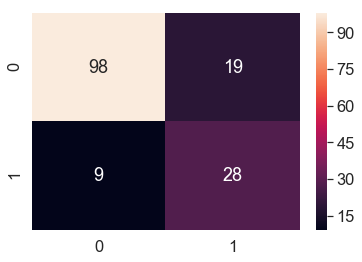

```python
from sklearn.linear_model import LogisticRegression, RidgeClassifier
from sklearn.metrics import confusion_matrix

#Model
LR = LogisticRegression()

#fiting the model
LR.fit(X_train, y_train)

#prediction
y_pred = LR.predict(X_test)

#Accuracy
print("Accuracy ", LR.score(X_test, y_test)*100)

#Plot the confusion matrix
sns.set(font_scale=1.5)
cm = confusion_matrix(y_pred, y_test)
sns.heatmap(cm, annot=True, fmt='g')
plt.show()
```